# Statistical learning - Basic models

## A brief description of the dataset

The *breastfeed* dataset for this work comes from a study conducted at a UK hospital, investigating the possible factors affecting the decision of pregnant women to breastfeed their babies. The outcome of the study could aid in targeting breastfeeding promotions towards women with a lower probability of choosing it. This will be an important aspect in this study, since it will motivate some decisions.

For the study, 139 expectant mothers were asked what kind of feeding method they would use for their coming baby. The responses were classified into two categories (and recorded in the factor variable *breast* in the dataset):

- the first category (breast = “Breast”, **class 1**) includes the cases “breastfeeding”, “try to breastfeed” and “mixed breast- and bottlefeeding”;
- the second category (breast = “Bottle”, **class 0**) corresponds to “exclusive bottle-feeding”.

The possible factors, that are available in the data, are:

- the advancement of the pregnancy (*pregnancy* variable),
- how the mothers were fed as babies (*howfed* variable),
- how the mother’s friend fed their babies (*howfedfr* variable),
- if they have a partner (*partner* variable),
- their age (*age* variable),
- the age at which they left full-time education (*educat* variable),
- their ethnic group (*ethnic* variable),
- if they have ever smoked (*smokebf* variable) and
- if they have stopped smoking (*smokenow* variable).

The variables *age* and *educat* are numerical, while all the other variables are categorical, with two possible values.

The goal of this study is to analyse the performance of different classification models on the given dataset and identify the model that provides the best classification accuracy.

The classification models that will be evaluated include logistic regression, k-nearest neighbors and Naïve Bayes.

We will assess the performance of each model using simple methods, since more advanced techniques (such as K-fold cross validation) are beyond the scope of this work. Various evaluation metrics, such as accuracy or average accuracy, will be used.

## Data exploration

```r
# Load the dataset
load("breastfeed.rdata")
bf <- breastfeed
as_tibble(bf)
```

| breast | pregnancy | howfed | howfedfr | partner | smokenow | smokebf | age | educat | ethnic |
| --- | --- | --- | --- | --- | --- | --- | --- | --- | --- |
| Breast | Beginning | Breast | Breast | Partner | No | No | 24 | 19 | Non-white |
| Breast | Beginning | Bottle | Breast | Partner | No | No | 27 | 18 | White |
| Bottle | Beginning | Breast | Breast | Partner | No | No | 39 | 16 | White |
| Bottle | Beginning | Breast | Breast | Partner | Yes | Yes | 29 | 16 | White |
| Breast | Beginning | Breast | Breast | Partner | No | No | 21 | 21 | White |
| Bottle | Beginning | Breast | Bottle | Partner | No | No | NA | 28 | White |
| Breast | Beginning | Breast | Breast | Partner | No | No | 27 | 19 | Non-white |
| Breast | Beginning | Breast | Breast | Partner | No | No | 27 | 22 | Non-white |
| Breast | Beginning | Breast | Bottle | Partner | Yes | Yes | 20 | 19 | Non-white |
| Breast | Beginning | Breast | Breast | Partner | No | Yes | 31 | 17 | White |

[output cut: 129 more lines]

We start with a quick exploration of the dataset, calling a summary in R.

```r
summary(bf)
```

```
##     breast        pregnancy     howfed     howfedfr     partner    smokenow
##  Bottle: 39   End      :84   Bottle:59   Bottle:54   Single : 21   No :107
##  Breast:100   Beginning:55   Breast:80   Breast:85   Partner:118   Yes: 32
##
##
##
##
##
##  smokebf       age            educat            ethnic
##  No :88   Min.   :17.00   Min.   :14.00   White    :80
##  Yes:51   1st Qu.:25.00   1st Qu.:16.00   Non-white:59
##           Median :28.00   Median :17.00
##           Mean   :28.26   Mean   :18.15
##           3rd Qu.:32.00   3rd Qu.:19.00
##           Max.   :40.00   Max.   :38.00
##           NA's   :2       NA's   :2
```

The summary reveals that there are two NA values for the numerical variable *age* and two NA for the numerical variable *educat*. Each one of these values will be substituted with the mean of the corresponding variable, rounded to the nearest integer (since the *age* and *educat* variables are positive integer variables). Alternatively, the 4 observations that contain NA values could be deleted. The latter approach is discarded since the given dataset has a quite small number of observations.

```r
# Coping with NA's

age_mean <- mean(bf$age, na.rm = TRUE)
bf$age[is.na(bf$age)] <- round(age_mean)

educat_mean <- mean(bf$educat, na.rm = TRUE)
bf$educat[is.na(bf$educat)] <- round(educat_mean)

# Check that there are no NA's
summary(bf)
```

```
##     breast        pregnancy     howfed     howfedfr     partner    smokenow
##  Bottle: 39   End      :84   Bottle:59   Bottle:54   Single : 21   No :107
##  Breast:100   Beginning:55   Breast:80   Breast:85   Partner:118   Yes: 32
##
##
##
##
##  smokebf       age            educat            ethnic
##  No :88   Min.   :17.00   Min.   :14.00   White    :80
##  Yes:51   1st Qu.:25.00   1st Qu.:16.00   Non-white:59
##           Median :28.00   Median :17.00
##           Mean   :28.26   Mean   :18.14
##           3rd Qu.:32.00   3rd Qu.:19.00
##           Max.   :40.00   Max.   :38.00
```

We can quickly check that there is low correlation between the two numerical variables *age* and *educat*.

```r
# Correlation between the two numerical variables
cor(bf %>% dplyr::select_if(is.numeric))
```

```
##              age    educat
## age    1.0000000 0.1893313
## educat 0.1893313 1.0000000
```

Another important thing to do is checking if there is **class imbalance** among the observations, as concerns the *breast* variable.

```r
# Total number of observations
tot <- dim(bf)[1]

# Number of observations in class 1
n_Breast <- sum(bf$breast == "Breast")

prop_Breast <- n_Breast/tot
sprintf("Proportion of observations in class 1: %f", prop_Breast)
```

```
## [1] "Proportion of observations in class 1: 0.719424"
```

```r
prop_Bottle <- (1 - prop_Breast)
sprintf("Proportion of observations in class 0: %f", prop_Bottle)
```

```
## [1] "Proportion of observations in class 0: 0.280576"
```

There is an evident class imbalance in the dataset:

- around **72%** of the observations belong to **class 1** (*breast* = “Breast”),
- around **28%** belong to **class 0** (*breast* = “Bottle”).

Being aware of the strong class imbalance, the dataset will be randomly split into test and training sets, maintaining in each set the same class imbalance as in the response variable *breast*.

The splitting will be created with the function “createDataPartition” from the “caret” package. Before each call of this function, a seed will be set for reproducibility. When evaluating the performance of the different classifiers, the same train-test partitions will be used.

Lastly, 70% of the observations will constitute the training set and the remaining 30% will be used to test the models.

## Logistic Regression

We now want to predict the *breast* target variable using a **multivariate Logistic Regression model**, with all the non-response variables as predictors.

Let’s set up the logistic regression model on the training set and give a look at the summary. We will set the threshold to get predictions from probabilities to be 0.5.

```r
glm.fits <- glm(breast ~ . ,
    data = bf,
    family = binomial,
    subset = train_index_bool)

summary(glm.fits)
```

```
##
## Call:
## glm(formula = breast ~ ., family = binomial, data = bf, subset = train_index_bool)
##
## Deviance Residuals:
##     Min       1Q   Median       3Q      Max
## -2.5109  -0.4647   0.2584   0.4902   2.7328
##
## Coefficients:
##                    Estimate Std. Error z value Pr(>|z|)
## (Intercept)        -2.64384    2.30375  -1.148   0.2511
## pregnancyBeginning -1.22412    0.64769  -1.890   0.0588 .
## howfedBreast       -0.05404    0.65811  -0.082   0.9346
## howfedfrBreast      1.14771    0.65233   1.759   0.0785 .
## partnerPartner      1.21782    0.78820   1.545   0.1223
## smokenowYes        -4.07517    1.30540  -3.122   0.0018 **
## smokebfYes          2.55911    1.29647   1.974   0.0484 *
## age                 0.03659    0.06031   0.607   0.5440
## educat              0.06119    0.11139   0.549   0.5828
## ethnicNon-white     2.35285    0.89812   2.620   0.0088 **
## ---
## Signif. codes:  0 '***' 0.001 '**' 0.01 '*' 0.05 '.' 0.1 ' ' 1
##
## (Dispersion parameter for binomial family taken to be 1)
##
##     Null deviance: 117.261  on 97  degrees of freedom
## Residual deviance:  71.553  on 88  degrees of freedom
## AIC: 91.553
##
## Number of Fisher Scoring iterations: 6
```

As shown in the summary, deviance residuals are well clustered around zero, indicating good fit. The most significant predictors are:

- **smokenowYes**: current smoking strongly decreases the odds of choosing breastfeeding;
- **smokebfYes**: having ever smoked increases the odds of breastfeeding;
- **ethnicNon-white**: non-white mothers are significantly more likely to choose breastfeeding.

Marginally significant predictors are:

- **pregnancyBeginning**: mothers in earlier pregnancy stages are less likely to choose breastfeeding (marginal significance at p = 0.0588);
- **howfedfrBreast**: if the mother’s friends fed their babies with breastfeeding, there is a positive but marginally significant effect (p = 0.0785).

We now evaluate the prediction accuracy on the test set.

```r
# Probabilities obtained
glm.probs <- predict(glm.fits, bf_test, type = "response")

# They are the probabilities of what?
contrasts(bf_train$breast)
```

```
##        Breast
## Bottle      0
## Breast      1
```

```r
# They are the probabilities of having breast = Breast (since that category is coded as 1)

# We turn probabilities into predictions using a threshold of 0.5
threshold <- 0.5
glm.pred <- rep("Bottle", nrow(bf_test))
glm.pred[glm.probs > threshold] <- "Breast"
```

```
## [1] "Number of observations in test set: 41"
```

```
## [1] "Confusion matrix:"
```

```
##
## glm.pred Bottle Breast
##   Bottle      4      2
##   Breast      7     28
```

As anticipated before, we wish to correctly classify all the women that choose exclusive bottle-feeding (*breast* = “Bottle”) in order to target breastfeeding promotions. Therefore, an important quantity to be kept as low as possible is the number (or proportion) of observations in the class *breast* = “Bottle” that are (wrongly) predicted as *breast* = “Breast”.

```r
Bottle_pred_as_Breast <- cm[2,1]
sprintf("Proportion of 'Bottle' (wrongly) predicted as 'Breast': %f", Bottle_pred_as_Breast/sum(cm[,1]))
```

```
## [1] "Proportion of 'Bottle' (wrongly) predicted as 'Breast': 0.636364"
```

Unfortunately, the prediction accuracy for the observations in class 0 is not so satisfactory.

Let’s measure the overall accuracy.

```r
# Accuracy
acc <- mean(glm.pred == bf_test[,1])
sprintf("Accuracy: %f", acc)
```

```
## [1] "Accuracy: 0.780488"
```

We could re-fit the model, after removing predictors that seem to have little or no relationship with the target, because such predictors will only cause an increase in variance, without a decrease in bias.

However, notice that the results obtained depend on the particular (random) train-test partition that has been generated. By varying the training and test sets, the results may change. Therefore, in order to take a more informed decision about the predictors to possibly discard and to have a better estimate of the accuracy of the model, we will fit the model multiple times and consider, for each predictor, the mean of the p-values obtained. Moreover, as an accuracy measure for this model, the mean of the various accuracy measures will be considered.

### Full logistic regression model (threshold = 0.5) with 100 repetitions

```r
# Number of times to fit the model
n_rep <- 100

# Create an empty vector to store the accuracy values
accuracies <- rep(0,n_rep)
prop_bottle_predas_breast <- vector(length = n_rep)

# Create an empty matrix to store the p-values of the predictors at each repetition
# - predictors on the rows
# - n. of repetition of the columns
results_df <- matrix(NA, nrow = ncol(bf), ncol = n_rep+1)

# Generate n_rep seeds for reproducibility
set.seed(57)
seeds_1 <- rdunif(n_rep,1,1000)

for (rep in seq(1:n_rep)) {

  set.seed(seeds_1[rep]) # for reproducibility

  # Generate train-test partition
  train_index <- createDataPartition(bf[, response_index], p = tp, list = FALSE, times = 1) #
  train_index_bool <- rep(FALSE,tot)
  train_index_bool[train_index] <- TRUE

  # Extract training and test sets
  bf_train <- bf[train_index, ]
  bf_test <- bf[-train_index, ]

  # Fit the model
  glm.fits <- glm(breast ~ . ,
      data = bf,
      family = binomial,
      subset = train_index_bool)

  # Get probabilities and predictions
  glm.probs <- predict(glm.fits, bf_test, type = "response")
  glm.pred <- rep("Bottle", nrow(bf_test))
  glm.pred[glm.probs > threshold] <- "Breast"

  # Confusion matrix
  cm <- table(glm.pred, bf_test[,1])
  # Proportion of Bottle predicted as Breast
  prop_bottle_predas_breast[rep] <- cm[2,1]/sum(cm[,1])


  # Store the results
  accuracies[rep] <- mean(glm.pred == bf_test[,1])

  pvalues_rep <- unname(summary(glm.fits)$coefficients[, 4])
  results_df[,rep] <- pvalues_rep

}


# In the last column of results_df, store the mean of the p-values of each predictor
for (row in seq(1:nrow(results_df))) {
  results_df[row,n_rep+1] <- mean(results_df[row,], na.rm = TRUE)
}
results_df <- as.data.frame(results_df)


# Modify row and columns names to make it more readable
cnames_results <- rep("p-values #", n_rep)
cnames_results <- paste0(cnames_results,1:n_rep)
colnames(results_df)[1:n_rep] <- cnames_results
colnames(results_df)[n_rep+1] <- "Average p-value"
rownames(results_df) <- dimnames(summary(glm.fits)$coefficients)[[1]]
```

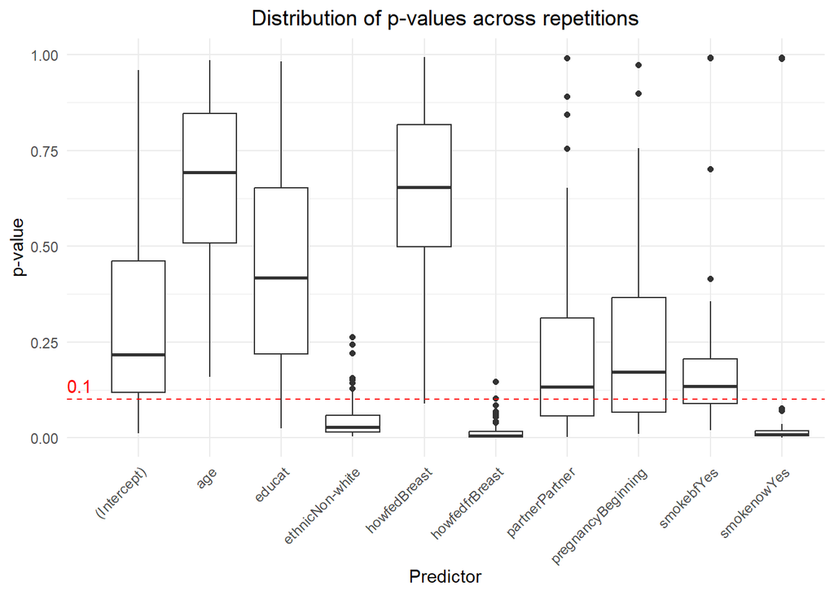

```r
# Convert results_df into long format for ggplot
results_long <- results_df %>%
  rownames_to_column("Predictor") %>%
  pivot_longer(
    cols = starts_with("p-values"),
    names_to = "Repetition",
    values_to = "PValue"
  ) %>%
  filter(Repetition != "Average p-value") # Exclude the average column

# Create the plot
p <- ggplot(results_long, aes(x = Predictor, y = PValue)) +
     geom_boxplot()

p <- p +
     geom_hline(yintercept = 0.10, linetype = "dashed", color = "red") +
     annotate("text", x = 0, y = 0.10, label = "0.1", color = "red", vjust = -0.5, hjust = 0) +
     labs(
       title = "Distribution of p-values across repetitions",
       x = "Predictor",
       y = "p-value"
       ) +
     theme_minimal() +
     theme(
       axis.text.x = element_text(angle = 45, hjust = 1), # Rotate x-axis labels
       plot.title = element_text(hjust = 0.5) # Center align title
       )
p
```

```r
# Show the results

sprintf("The model was fit %d times.", n_rep)
```

```
## [1] "The model was fit 100 times."
```

```r
av_acc_LR_1 <- mean(accuracies)
sprintf("Average accuracy: %f", av_acc_LR_1)
```

```
## [1] "Average accuracy: 0.795610"
```

```r
print("Average p-values:")
```

```
## [1] "Average p-values:"
```

```r
results_df["Average p-value"]
```

|  | Average p-value |
| --- | --- |
| (Intercept) | 0.30320000 |
| pregnancyBeginning | 0.24871372 |
| howfedBreast | 0.64628679 |
| howfedfrBreast | 0.01500364 |
| partnerPartner | 0.21037764 |
| smokenowYes | 0.06082483 |
| smokebfYes | 0.19937945 |
| age | 0.66427395 |
| educat | 0.45702226 |
| ethnicNon-white | 0.04379163 |

```r
average_prop_Bottle_predas_Breast_1 <- mean(prop_bottle_predas_breast)
sprintf("Average proportion of 'Bottle' (wrongly) predicted as 'Breast': %f", average_prop_Bottle_predas_Breast_1)
```

```
## [1] "Average proportion of 'Bottle' (wrongly) predicted as 'Breast': 0.416364"
```

### Simpler logistic regression model

```r
# Create empty vectors to store the accuracy values
accuracies_simpler <- rep(0,n_rep)
prop_bottle_predas_breast_simpler <- vector(length = n_rep)

for (rep in seq(1:n_rep)) {

  set.seed(seeds_1[rep]) # Use same seeds as before

  # Train-test partition
  train_index <- createDataPartition(bf[, response_index], p = tp, list = FALSE, times = 1)
  train_index_bool <- rep(FALSE,tot)
  train_index_bool[train_index] <- TRUE

  # Training and test sets
  bf_train <- bf[train_index, ]
  bf_test <- bf[-train_index, ]

  # Fit the simpler model
  glm.fits2 <- glm(breast ~ smokenow + smokebf + ethnic,
      data = bf,
      family = binomial,
      subset = train_index_bool)

  # Get probabilities and predictions
  glm.probs2 <- predict(glm.fits2, bf_test, type = "response")
  glm.pred2 <- rep("Bottle", nrow(bf_test))
  glm.pred2[glm.probs2 > threshold] <- "Breast"

  # Store results
  accuracies_simpler[rep] <- mean(glm.pred2 == bf_test[,1])

  # Confusion matrix
  cm <- table(glm.pred, bf_test[,1])
  # Proportion of Bottle predicted as Breast
  prop_bottle_predas_breast_simpler[rep] <- cm[2,1]/sum(cm[,1])

}
```

```
## [1] "The simpler model was fit 100 times."
```

```
## [1] "Average accuracy of the simpler model: 0.833659"
```

```
## [1] "Average proportion of 'Bottle' (wrongly) predicted as 'Breast': 0.657273"
```

As shown, the average accuracy improves by approximately 3.8% with the simpler model. However, this model also results in a higher number of ‘Bottle’ observations being incorrectly classified as ‘Breast’.

To reduce the proportion of misclassified “Bottle” observations, we can increase the threshold for converting probabilities into predictions. Since the probabilities represent the likelihood of breast = “Breast”, using a higher threshold (e.g., 0.75) makes the model more conservative when predicting “Breast.” This adjustment aims to improve classification accuracy for the “Bottle” category.

### Full logistic regression model with threshold = 0.75

```r
threshold <- 0.75

# Create empty vectors to store the accuracy values
accuracies <- rep(0,n_rep)
prop_bottle_predas_breast <- vector(length = n_rep)

for (rep in seq(1:n_rep)) {

  set.seed(seeds_1[rep]) # Use same seeds as before

  # Train-test partition
  train_index <- createDataPartition(bf[, response_index], p = tp, list = FALSE, times = 1) #
  train_index_bool <- rep(FALSE,tot)
  train_index_bool[train_index] <- TRUE

  # Training and test sets
  bf_train <- bf[train_index, ]
  bf_test <- bf[-train_index, ]

  # Fit the simpler model
  glm.fits <- glm(breast ~ . ,
      data = bf,
      family = binomial,
      subset = train_index_bool)

  # Get probabilities and predictions
  glm.probs <- predict(glm.fits, bf_test, type = "response")
  glm.pred <- rep("Bottle", nrow(bf_test))
  glm.pred[glm.probs > threshold] <- "Breast"

  # Confusion matrix
  cm <- table(glm.pred, bf_test[,1])
  # Proportion of Bottle predicted as Breast
  prop_bottle_predas_breast[rep] <- cm[2,1]/sum(cm[,1])

  # Store results
  accuracies[rep] <- mean(glm.pred == bf_test[,1])

}
```

```r
# Show the results (threshold = 0.75)

sprintf("The model was fit %d times with a threshold of %.2f.", n_rep, threshold)
```

```
## [1] "The model was fit 100 times with a threshold of 0.75."
```

```r
av_acc_LR_2 <- mean(accuracies)
sprintf("Average accuracy: %f", av_acc_LR_2)
```

```
## [1] "Average accuracy: 0.760244"
```

```r
average_prop_Bottle_predas_Breast_2 <- mean(prop_bottle_predas_breast)
sprintf("Average proportion of 'Bottle' (wrongly) predicted as 'Breast': %f", average_prop_Bottle_predas_Breast_2)
```

```
## [1] "Average proportion of 'Bottle' (wrongly) predicted as 'Breast': 0.244545"
```

We have got a lower accuracy, but we have improved the accuracy in correctly classifying the “Bottle” observations. By increasing the threshold even more, a slightly better classification performance can be achieved on observations from class 0, but the average overall accuracy starts to decrease significantly.

## K-Nearest Neighbors

In this section, we will fit a k-nearest neighbors (k-NN) classifier using the *knn* function from the class package. Since the *knn* function only supports numerical predictors, categorical variables will be converted to numerical form using one-hot encoding. This process involves generating dummy variables for each categorical variable, which will be accomplished using the *dummyVars* function from the *caret* package.

```r
# One-hot encoding of the dataset
bf_dummy <- dummyVars(~ . , data = bf %>% dplyr::select(-breast), fullRank = TRUE) %>% predict(bf)
bf_dummy <- as.data.frame(bf_dummy)
# Dataframe that contains the breast variable and all numerical variables
bf_knn <- cbind(bf$breast,bf_dummy)
```

Different values of k will be used, and for each value of k, the model will be fit multiple times, using the same train-set partitions as before. Lastly, for each value of k, the average accuracy will be computed.

```r
# Run k-nn for different values of k and for each k fit the model 5 times.
# Consider the average accuracy for each k.

# Maximum number of neighbours
max_n_nb <- 10

# Matrix of accuracies
acc_knn <- matrix(NA, nrow = max_n_nb, ncol = n_rep )

# I will need n_rep seeds to use for each value of k
#set.seed(57)
#seeds_2 <- rdunif(n_rep, 1, 1000)

for (n_nb in seq(1:max_n_nb)) {

  for (rep in seq(1:n_rep)) {

    set.seed(seeds_1[rep])

    tp = 0.7 # Training test proportion
    train_index <- createDataPartition(bf[, response_index], p = tp, list = FALSE)

    # Training and test sets
    trainset   <- bf_knn[train_index, 2:ncol(bf_knn)]
    testset    <- bf_knn[-train_index, 2:ncol(bf_knn)]

    # Fit knn
    knn.pred <- knn(trainset, testset, bf$breast[train_index], k = n_nb)

    # Compute and store accuracy
    acc_knn[n_nb, rep] <- mean(knn.pred == bf$breast[-train_index])

  }
}


# Average accuracy for each value of k
average_acc_knn <- vector(length = max_n_nb)
for (i in seq(1:max_n_nb)) {
  average_acc_knn[i] <- mean(acc_knn[i,])
}
```

```r
# Print results
sprintf("For each value of k the model has been fit %d times.", n_rep)
```

```
## [1] "For each value of k the model has been fit 100 times."
```

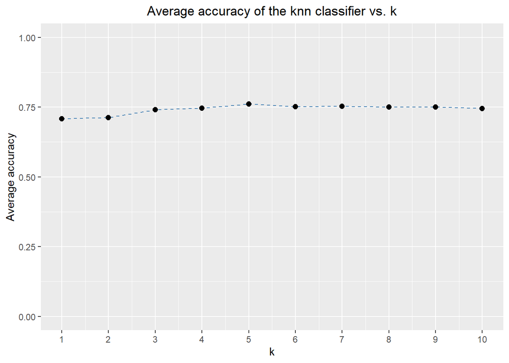

```r
# Plot accuracy vs k
df_acc_vs_k <- data.frame(k = seq(1:max_n_nb),
                          average_accuracy = average_acc_knn)


ggplot(data = df_acc_vs_k, aes(x = k, y = average_accuracy)) +
  geom_line(linetype = "dashed", color = "steelblue") +
  geom_point(size = 2.2) +
  ylim(0, 1) +
  ggtitle("Average accuracy of the knn classifier vs. k") +
  xlab("k") +
  ylab("Average accuracy") +
  theme(plot.title = element_text(hjust = 0.5)) +
  scale_x_continuous(breaks = seq(1:max_n_nb))
```

The best accuracy is achieved by k=5. Moreover, since the trend suggest a decrease in average accuracy for larger values of k, this choice seems to be the best one, as concerns having a good bias-variance trade off.

However, the logistic regression model still performed better.

We could further investigate how well the 5-nn classifier performs on observations for which *breast* = “Bottle”.

```r
# 5-nearest neighbors
chosen_k <- 5
acc_5nn <- vector(length = n_rep)
prop_Bottle_pred_as_Breast_5nn <- vector(length = n_rep)

for (rep in seq(1:n_rep)) {

  set.seed(seeds_1[rep])
  tp = 0.7
  train_index <- createDataPartition(bf[, response_index], p = tp, list = FALSE)
  trainset   <- bf_knn[train_index, 2:ncol(bf_knn)]
  testset    <- bf_knn[-train_index, 2:ncol(bf_knn)]

  five_nn.pred <- knn(trainset, testset, bf$breast[train_index], k = chosen_k)

  acc_5nn[rep] <- mean(five_nn.pred == bf$breast[-train_index])
  cm_5nn <- table(five_nn.pred, bf_test[,1])
  prop_Bottle_pred_as_Breast_5nn <- cm_5nn[2,1]/sum(cm_5nn[,1])

  }
```

```r
# Show results
sprintf("Average accuracy of the 5-nn classifier: %f", mean(acc_5nn))
```

```
## [1] "Average accuracy of the 5-nn classifier: 0.761220"
```

```r
sprintf("Average proportion of 'Bottle' (wrongly) classified as 'Breast': %f", mean(prop_Bottle_pred_as_Breast_5nn))
```

```
## [1] "Average proportion of 'Bottle' (wrongly) classified as 'Breast': 0.636364"
```

Unfortunately, the average proportion of ‘Bottle’ (wrongly) classified as ‘Breast’ is significantly high.

## Naïve Bayes

Lastly, we are going to fit a Naïve Bayes classifier. As before, the model will be fit multiple times and the average accuracy will be considered. The function *naiveBayes* from the package *e1071* will be used.

```r
# Vector of accuracies
acc_nb <- vector(length = n_rep)

for (rep in seq(1:n_rep)) {

  set.seed(seeds_1[rep]) # same seeds as before

  # Create the train and test partition
  train_index <- createDataPartition(bf[, response_index], p = tp, list = FALSE, times = 1)

  # Training and test sets
  bf_train <- bf[train_index,]
  bf_test <- bf[-train_index,]

  # Fit Naive Bayes classifier
  nbayes.fits <- naiveBayes(breast ~ ., data = bf_train)
  nbayes.pred <- predict(nbayes.fits, bf_test %>% select(-breast), type = "class")

  # Accuracy
  acc_nb[rep] <- mean(nbayes.pred == bf_test$breast)
  cm_nb <- table(nbayes.pred, bf_test$breast)
  prop_Bottle_pred_as_Breast_nb <- cm_nb[2,1]/sum(cm_nb[,1])

}
```

```r
# Show results
sprintf("The model was fit %d times", n_rep)
```

```
## [1] "The model was fit 100 times"
```

```r
print("Average accuracy:")
```

```
## [1] "Average accuracy:"
```

```r
av_acc_nb <- mean(acc_nb)
print(av_acc_nb)
```

```
## [1] 0.7917073
```

```r
av_prop_Bottle_predas_Breast_nbb <- mean(prop_Bottle_pred_as_Breast_nb)
sprintf("Average proportion of 'Bottle' (wrongly) classified as 'Breast': %f", av_prop_Bottle_predas_Breast_nbb)
```

```
## [1] "Average proportion of 'Bottle' (wrongly) classified as 'Breast': 0.363636"
```

## Conclusions

To conclude, the most important results of the work are reported.

| Model | Average_accuracy | Prop_Bottle_pred.as_Breast |
| --- | --- | --- |
| full LR model with t = 0.5 | 0.7956098 | 0.4163636 |
| full LR model with t = 0.75 | 0.7602439 | 0.2445455 |
| 5-nn | 0.7612195 | 0.6363636 |
| NaiveBayes | 0.7917073 | 0.3636364 |